# Model methods

C. Susannah Tysor

2021-06-25

## Data

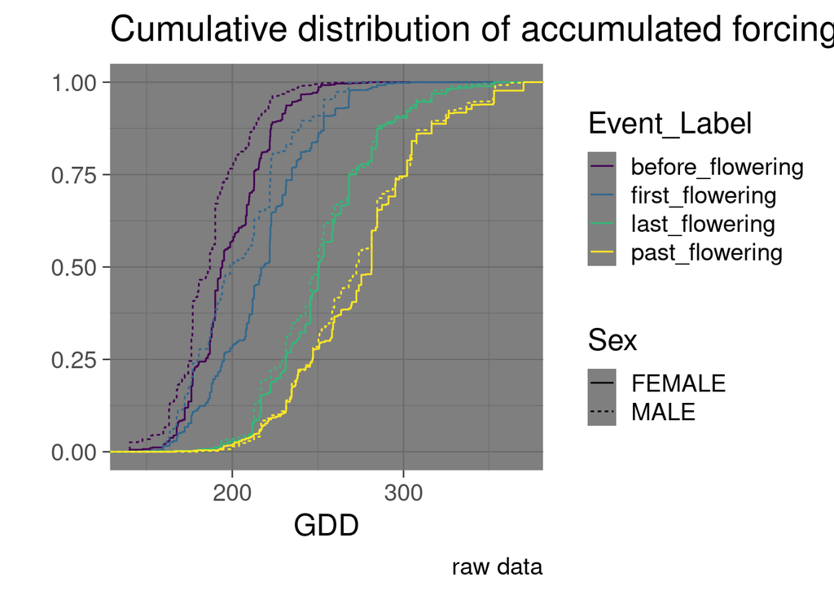

Make censorship tables (proportion?)

```
## # A tibble: 7 x 3
## # Groups:   Site [7]
##   Site        FEMALE  MALE
##   <chr>        <int> <int>
## 1 Kalamalka        4    11
## 2 KettleRiver     14     2
## 3 PGTIS          910  1710
## 4 PRT              7     8
## 5 Sorrento         2     1
## 6 Tolko           NA    12
## 7 Vernon          17    18
```

```
## # A tibble: 3 x 3
## # Groups:   Site [3]
##   Site        FEMALE  MALE
##   <chr>        <int> <int>
## 1 Kalamalka        1    NA
## 2 KettleRiver      1     1
## 3 PGTIS         1365  1393
```

```
## # A tibble: 4 x 4
## # Groups:   Sex, Event_Label, censored [4]
##   Sex    Event_Label     censored proportion
##   <chr>  <chr>           <chr>         <dbl>
## 1 FEMALE first_flowering left           0.37
## 2 FEMALE last_flowering  right          0.53
## 3 MALE   first_flowering left           0.65
## 4 MALE   last_flowering  right          0.52
```

## Model

We built separate hierarchical Bayesian intercept-only factor models of the accumulated forcing at each of the four flowering events of interest: start of receptivity (female begin), end of receptivity (female end), start of pollen shed (male begin), and end of pollen shed (male end).

Ideally, the likelihood of begin and end of flowering observations $y_i$ would

$y_i \sim \mathrm{Normal}(\phi_i, \sigma)$

Flowering start data is left censored when a tree is already flowering when it is first observed, so the likelihood is calculated with a cumulative normal distribution function.

$\mathrm{y_i} \sim \mathrm{Cumulative Normal}(\phi_i,\sigma)$

Flowering end data is right censored when a tree is never observed past flowering and a complementary cumulative normal distribution function is used for the likelihood.

$\mathrm{y_i} \sim \mathrm{Complementary Cumulative Normal}(\phi_i, \sigma)$.

Mean $\phi_i$ is the sum of the overall population mean $\mu$ and offsets $\delta$ for each level of factors Site, Provenance, Year, and Clone.

$\mathrm{\phi_i} = \mu + \delta_{Site, i} + \delta_{Provenance, i} + \delta_{Year, i} + \delta_{Clone, i}$

Priors limit parameter estimates to forcing accumulations possible at our sites during late spring, when lodgepole pine are known to flower in British Columbia (@owensReproductiveBiologyLodgepole2006). Offset standard deviations $\sigma_{factor}$ were roughly constrained by both estimates of possible forcing accumulation and the approximately known length of the flowering period. Possible forcing accumulation ranges were calculated using daily PCIC weather data from 1945-2012 at all of our sites. As Site, Provenance, and Year have relatively few levels with which to estimate $\sigma_{factor}$, half normal priors with their relatively thin tails were used to help constrain the parameter. Additional details on prior choice can be found in the conceptual analysis (supplementary materials).

Priors for the begin models differ for those of the end models as forcing accumulates faster in later spring than early spring and flowering must begin before it can end.

Models were fit in Stan (`rstan` vers. 2.21.2 [@standevelopmentteam2020]) via the R (R version 4.0.3 (202-10-10)) package `brms` (vers. 2.15.0 [@Burkner2017a]). Stan uses the No-U-Turn Sampler, an efficient Markov Chain Monte Carlo method that extends the Hamiltonian Monte Carlo algorithm [@carpenter2017], to sample the joint posterior.

### Diagnostics

We ran 6 independent chains of 4000 iterations each. 2000 warmup iterations were dropped from each chain for 1.2^{4} total samples. Model convergence and performance were considered good; $\hat R$ was $< 1.01$ and bulk and tail effective sample size was more than 100x the number of chains for all parameter values in all models [@vehtari2019]. There were no divergences. Visual inspection of energy plots and rank plots showed acceptable sampling behavior.

# Results

For efficiency, 2000 posterior samples were used for plotting results.

## Means

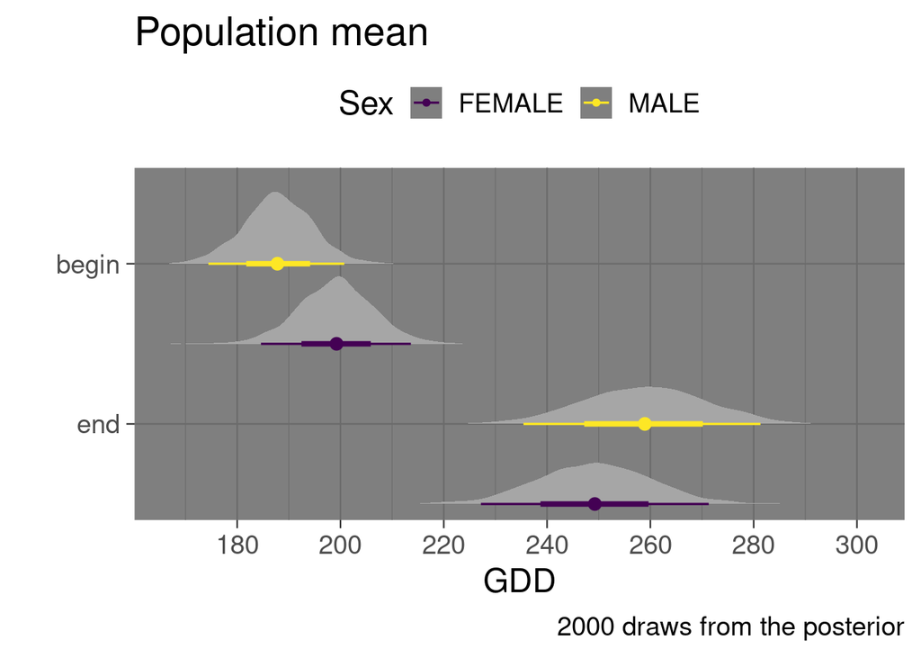

Overall variation in flowering is ~15 forcing units for start and 17 for end. In general, variation is smaller for start events than end events, likely because forcing increases monotonically.

Estimates for variation among Year, Site, and Provenance are relatively uncertain because the number of levels within each of these factors was small (7-15), while there were hundreds of clones and trees.

Within-clone variance (sd Tree) is very low, but higher for males than females. Mean estimates of variation within provenance (among Clone variation) is higher than variation among provenances, but the posterior is quite wide for Provenance and the posterior has a great deal of weight beyond the upper limits of the Clone estimates.

Year explains more of the variation than all other factors except for the female end model where Site is more important.

Year: me, fe, mb, fb Site: fe, me, fb, mb Prov: me, fe, fe, mb Clone: fe, me, fb, mb Tree: me, mb, fb, fe

## Variation

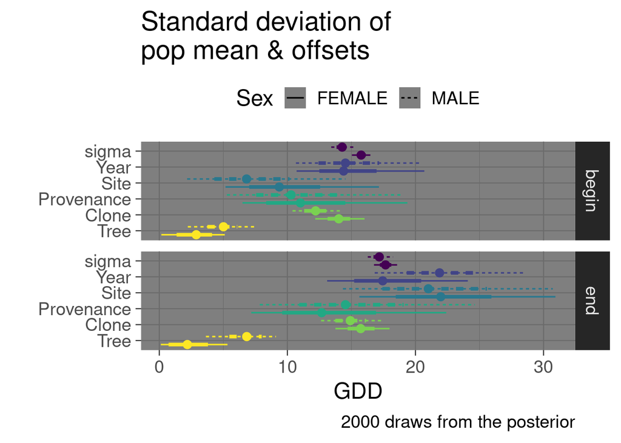

Effects for Tree are generally quite small and are moderate for Provenance. Clone has a wide range of possible effects. PGTIS and PRT have relatively large effects for the end of flowering, tending to stop flowering at a larger forcing amount. (Maybe because of censoring?) Provenances have similar ranked effects across models and events, tending to skew events earlier or later by a small amount of forcing.

## Offsets

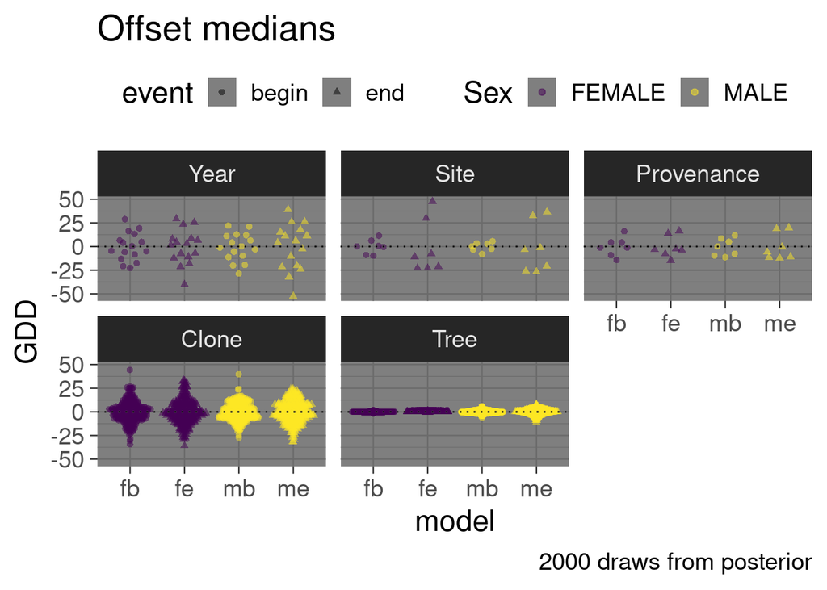

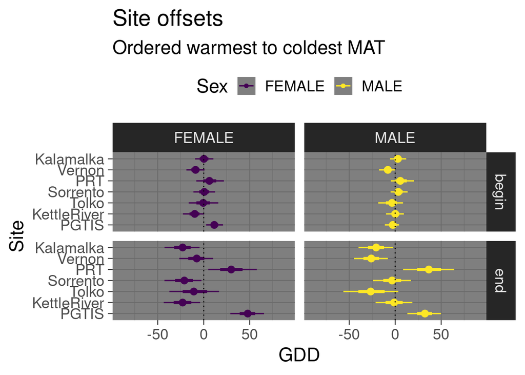

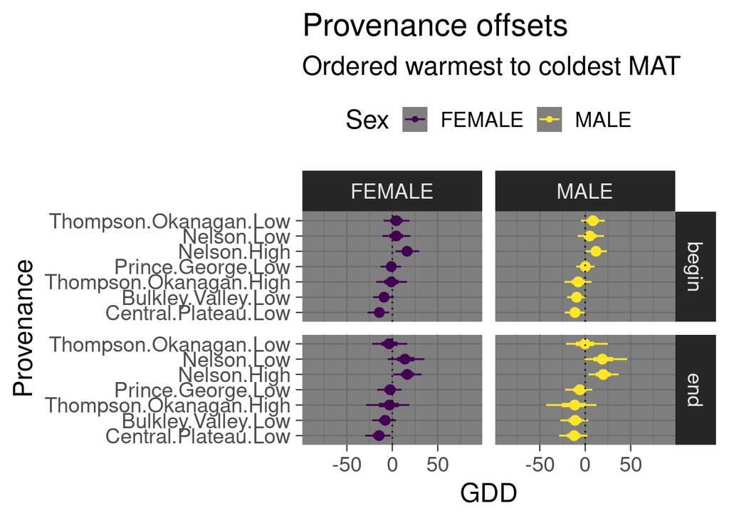

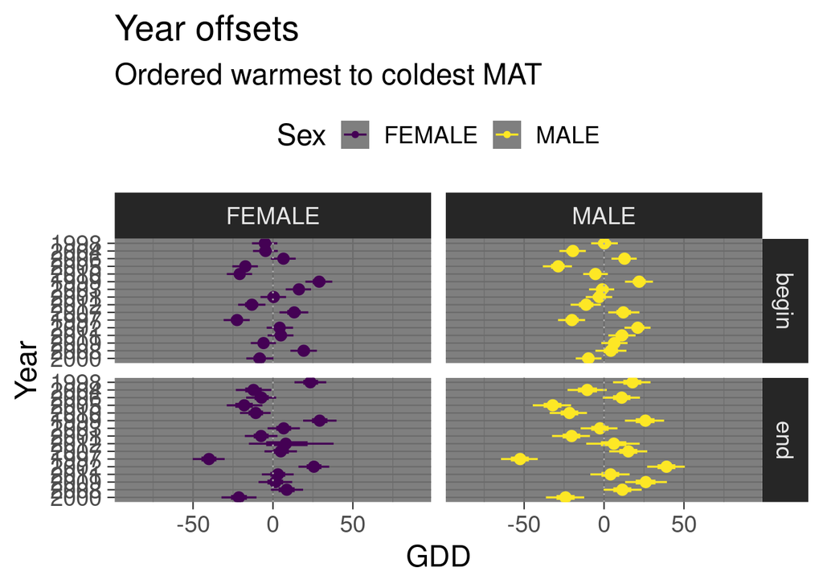

# Retrodictions

## General predictions

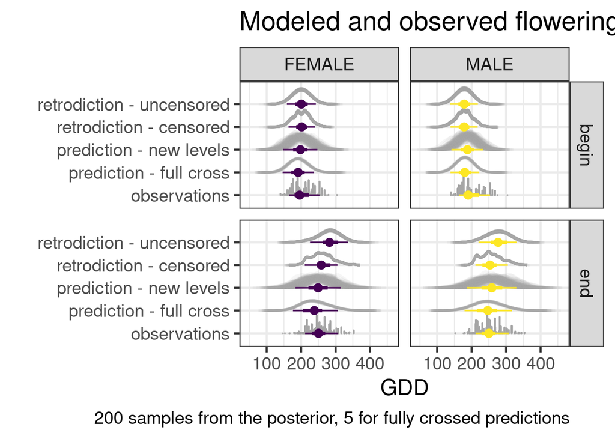

We used the model to simulate four data sets. First we retrodicted flowering forcing for the observed combinations of trees, clones, years, provenances, and sites (retrodiction - uncensored). Then we censored that data based on the censoring points recorded in our observations (retrodiction - censored). We expect the censored retrodictions to match our observations relatively well.

We also predicted flowering forcing for a fully crossed version of our original dataset and for new sites, years, provenances, clones, and trees. Since the fully-crossed version of our originally observed data set is 82,768 rows for each sex + event, only 5 samples from the posterior were used to simulate each observation. For new levels, we predicted 1500 forcing observations for all 4 flowering events. We sampled offsets for 5 new sites, years and provenances from the superpopulation posterior distributions for each factor offset ($\mathrm{Normal}(0, \sigma_{factor})$). Each provenance was represented by 10 clones with 2 ramets each.

All simulations used the same 200 draws from the posterior, except for the fully crossed version which used the same 5 which were a subset of the previous 200.

# Add days to preds

See functions in retrodiction functions for this.

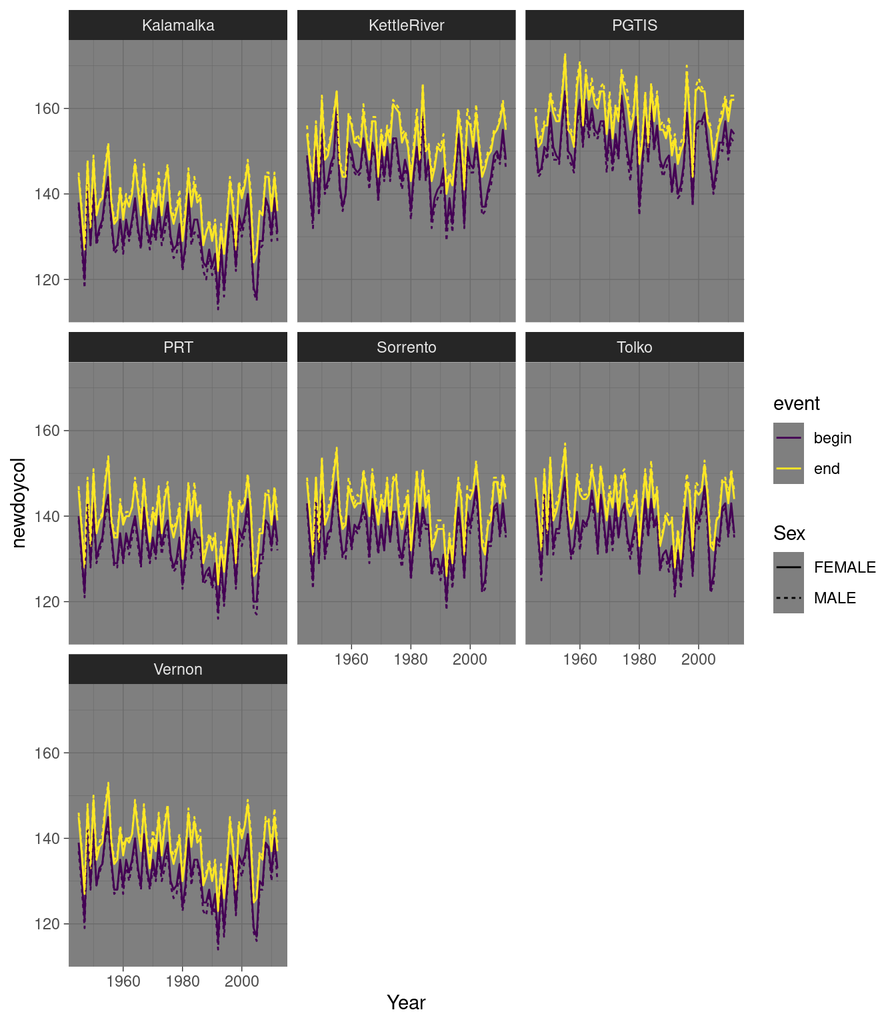

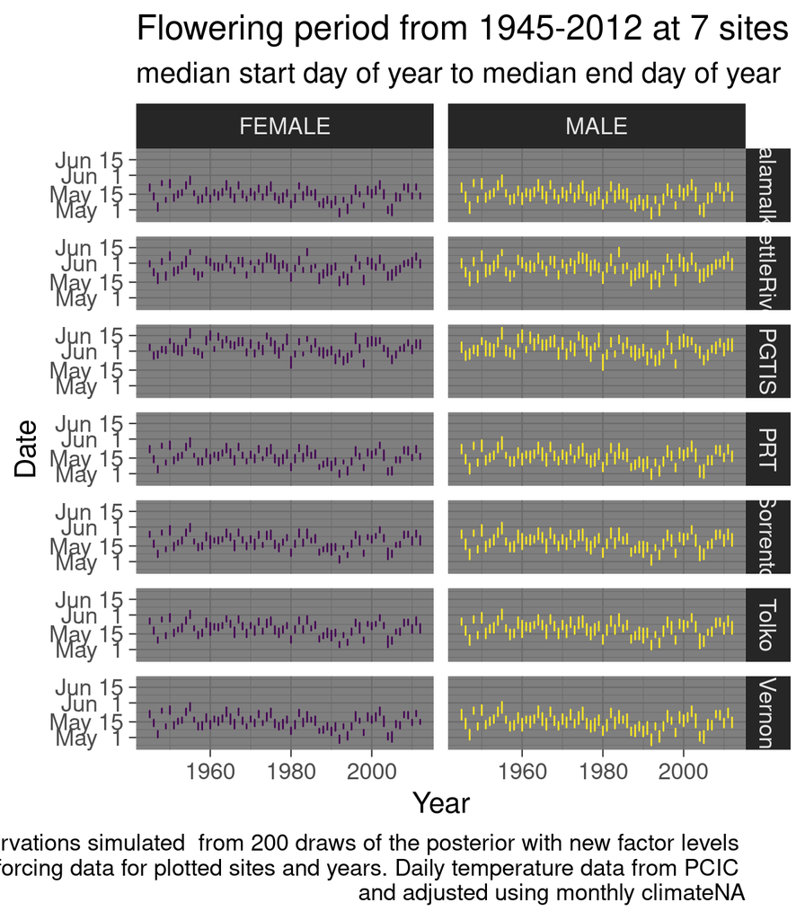

# Climate change

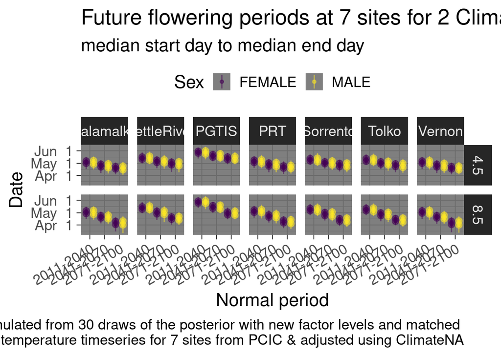

Date of flowering is earlier as climate change progresses - by quite a lot under some climate change scenarios.

# length

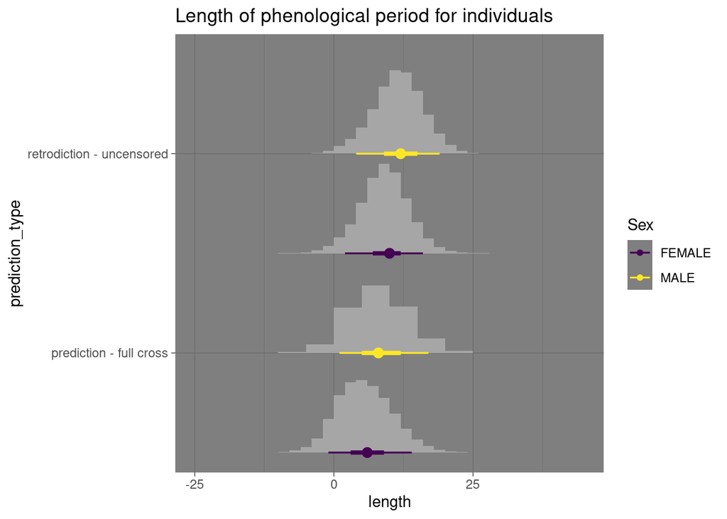

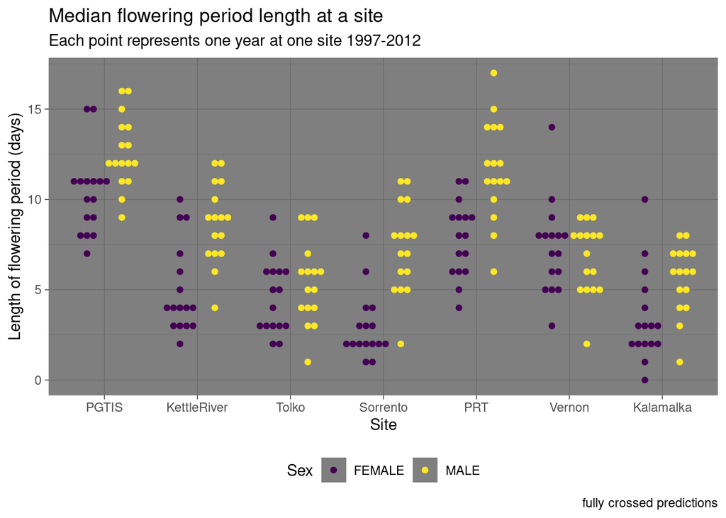

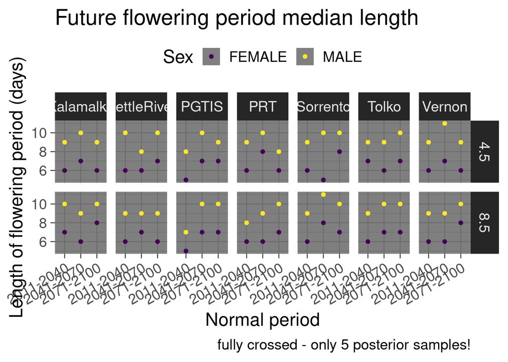

Haven’t figured out a good graph for future length yet. Not sure it’s really doing anything?